# Modeling and Optimization

Introduction to Integer Programming

Sebastian Souyris

MGMT 6460 Fall 2026

## Roadmap

1. Why Integer Programming?
2. A Total Integer Model: The Machine Shop
3. Integer Models in Excel Solver
4. A 0–1 Integer Model: Recreation Facilities
5. A Mixed Integer Model: Investments
6. 0–1 Modeling Patterns
7. Practice: Salespeople Transfer
8. Conclusions

# Why Integer Programming?

## When Fractions Make No Sense

- Linear programming assumes **divisibility**: any fractional activity level is allowed
- Many decisions come in whole units: machines to buy, people to transfer, warehouses to open, projects to fund
- Some decisions are pure yes/no: build the pool or not, open the hub or not

**Integer Programming (IP)**

A linear program in which some or all decision variables must take **integer** values. Same linear objective, same linear constraints, one extra requirement that changes everything about how we solve it.

## Three Types of Integer Models

**Total integer model**

**All** decision variables must be integers. Example: how many presses and lathes to buy.

**0–1 integer model**

All decision variables must be **0 or 1**: a yes/no decision per activity. Example: which facilities to build.

**Mixed integer model**

**Some** variables integer, the rest continuous. Example: whole condominiums plus fractional acres of land.

# A Total Integer Model: The Machine Shop

## The Machine Shop

A machine shop is adding new presses and lathes.

- Marginal profitability: each press **$100/day**, each lathe **$150/day**
- Resource limits: **$40,000** budget and **200 sq ft** of floor space

| Machine | Floor space (sq ft) | Purchase price |
| --- | --- | --- |
| Press | 15 | $8,000 |
| Lathe | 30 | $4,000 |

**The catch**

Nobody buys 2.22 presses. Both decisions are whole numbers.

## The Machine Shop Model

**Total integer model: $x_1$ presses, $x_2$ lathes**

$$\begin{array}{l@{\;\;}r@{\;}r@{\;}c@{\;}l@{\quad}l}
\max~ Z = & 100x_1 & {}+150x_2 \\
\text{subject to} & 8{,}000x_1 & {}+4{,}000x_2 & \le & 40{,}000 & \text{(budget, \$)} \\
& 15x_1 & {}+30x_2 & \le & 200 & \text{(floor space, sq ft)} \\
& \rlap{x_1,\; x_2 \ge 0 \text{ and integer}}\phantom{8{,}000x_1}
\end{array}$$

- Drop the last line and this is an ordinary LP: the **LP relaxation**
- Two variables, so the graph shows exactly what the integer requirement does

## Graphical View: The Feasible Points

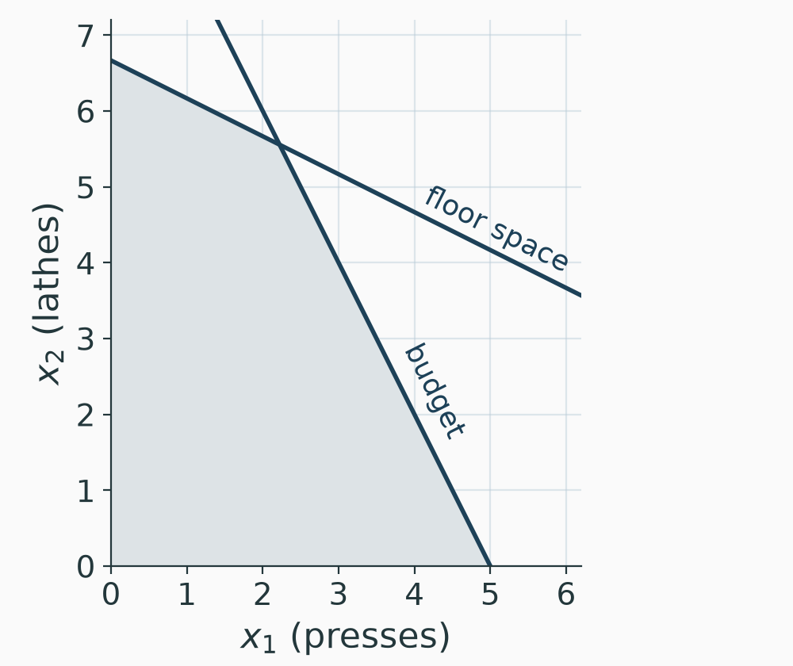

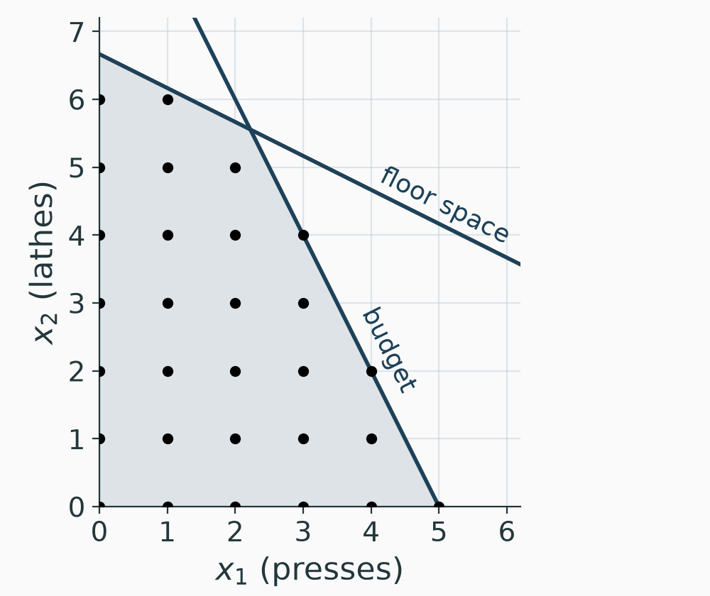

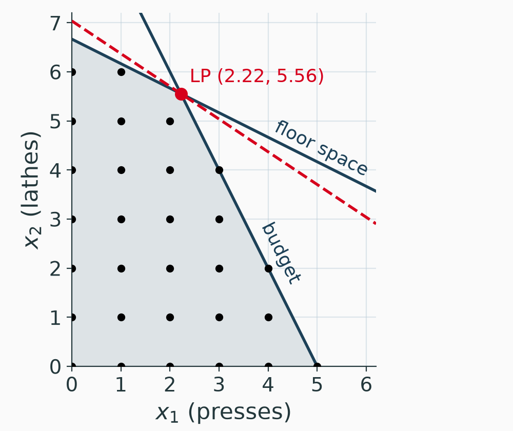

**LP relaxation.** Every point in the shaded region satisfies the budget and floor space limits.

**Integer feasible set.** Only the **lattice points** inside the region qualify: 29 candidates.

**LP optimum.** $(2.22,\,5.56)$ with $Z = 1{,}055.56$ is fractional, so it is not a candidate.

**Question**

Where is the best lattice point?

## Rounding Is a Trap

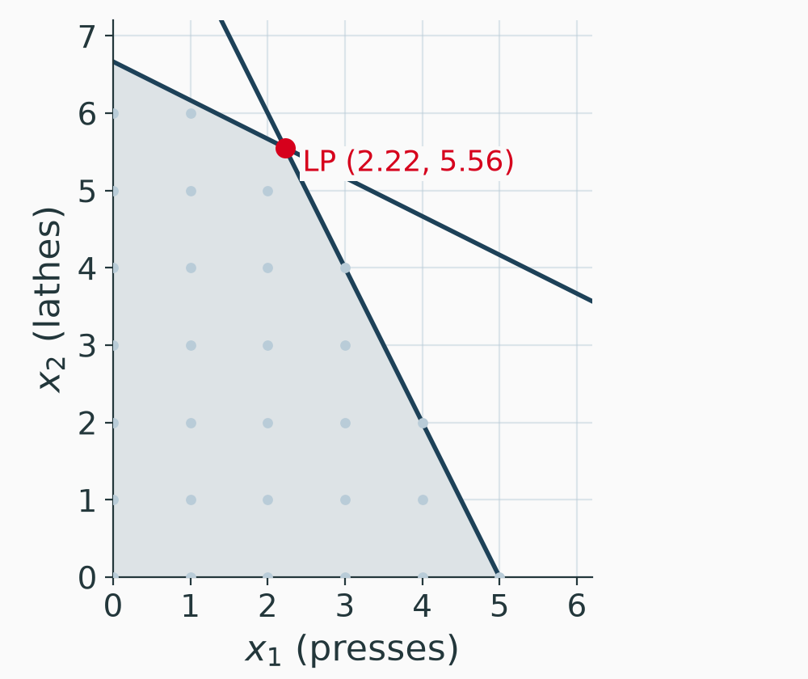

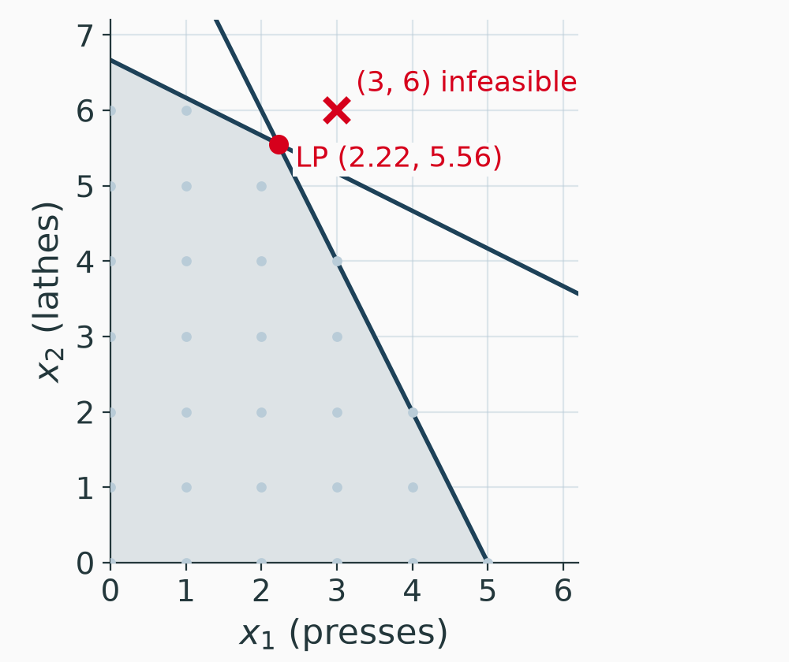

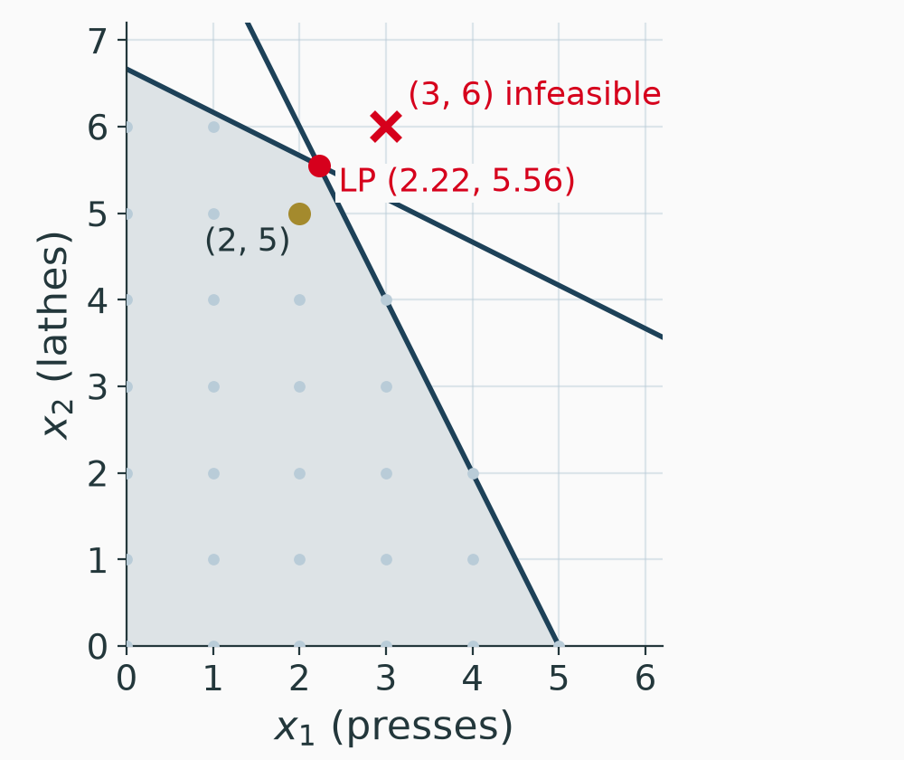

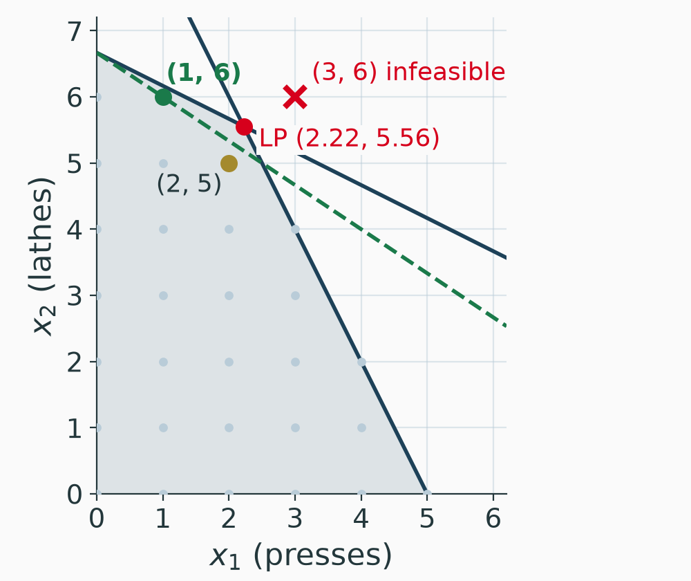

The LP optimum is $(2.22,\,5.56)$, $Z = 1{,}055.56$. Round it?

**Round up: $(3,6)$.** Infeasible. Budget 48,000 $>$ 40,000; space 225 $>$ 200.

**Round down: $(2,5)$.** Feasible, $Z = 950$. Safe for $\le$ constraints, but it leaves $50 a day on the table.

**Optimum: $(1,6)$**

$Z = 1{,}000$. One variable rounds down, the other **up**. No rounding rule finds this in general.

## Branch and Bound: The Idea

Rounding fails, and enumeration explodes with the number of variables. **Branch and bound** splits the feasible set into pieces, solves an LP on each, and uses the LP values as *bounds* to discard whole pieces unexplored.

**The three moves**

1. **Relax**: solve the LP without integer requirements. Its value is an upper bound (for a max problem).
2. **Branch**: pick a fractional variable, $x_2 = 5.56$, and split into $x_2 \le 5$ and $x_2 \ge 6$. No integer point is lost.
3. **Bound**: fathom any infeasible piece, and any piece whose LP value cannot beat the best integer solution found so far (the *incumbent*).

## Branching on the Graph

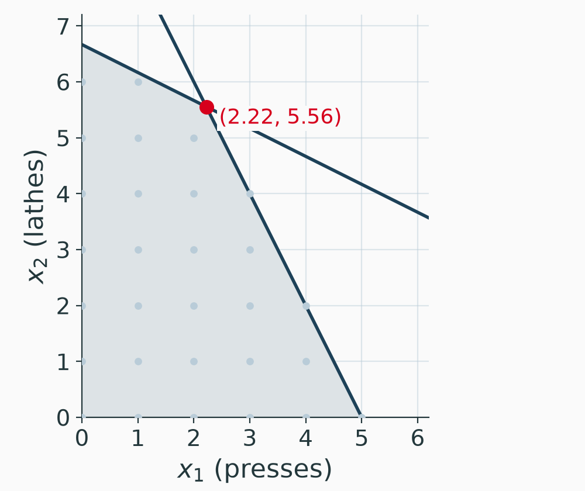

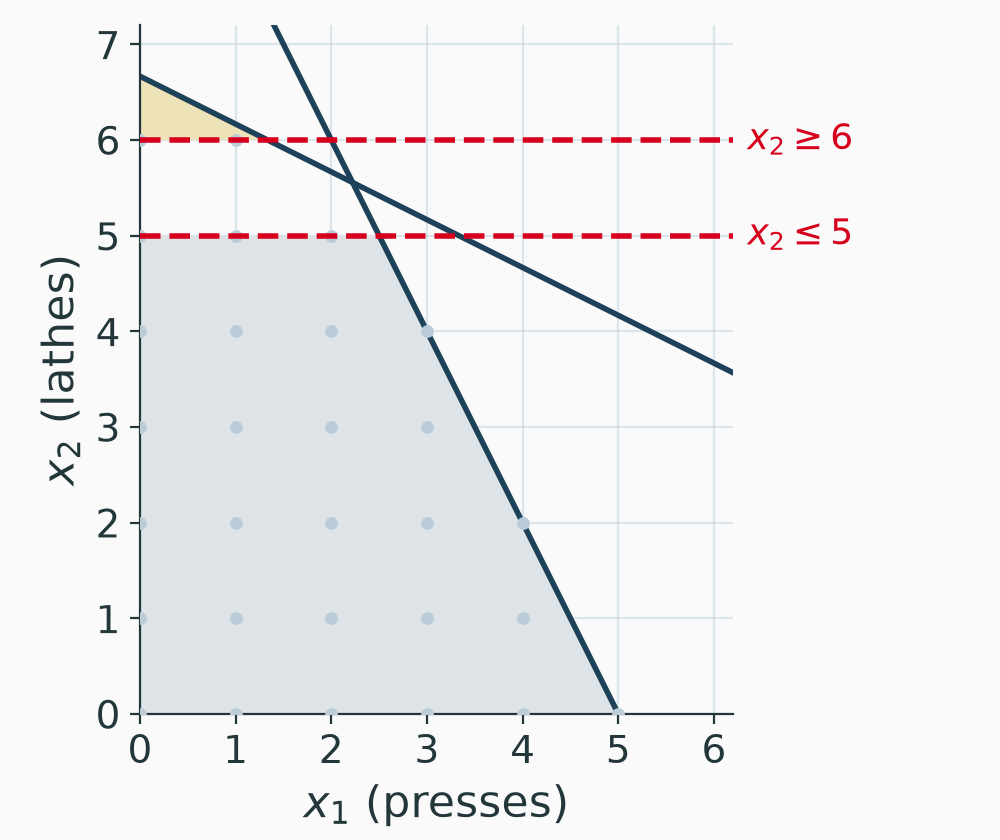

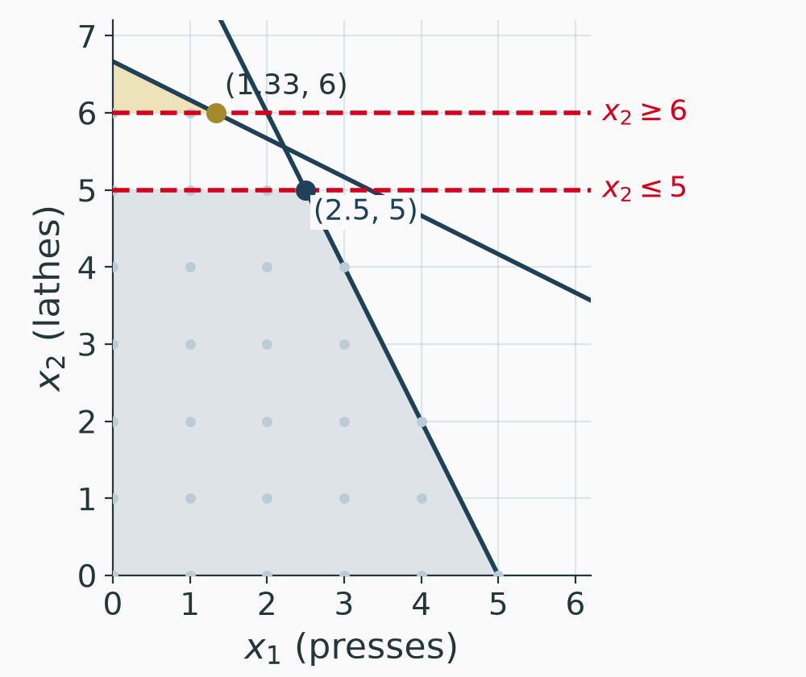

**Node 0: the relaxation.** $(2.22,\,5.56)$, $Z = 1{,}055.56$. The value $x_2 = 5.56$ is fractional, so branch on $x_2$.

**Two subproblems.** Add $x_2 \le 5$ or $x_2 \ge 6$. The strip between holds no integer point, so nothing feasible is lost.

**Solve each LP**

$x_2 \le 5$: $(2.5,\,5)$, $Z = 1{,}000$.  
$x_2 \ge 6$: $(1.33,\,6)$, $Z = 1{,}033.33$.  
Both fractional: keep going.

## The Branch and Bound Tree

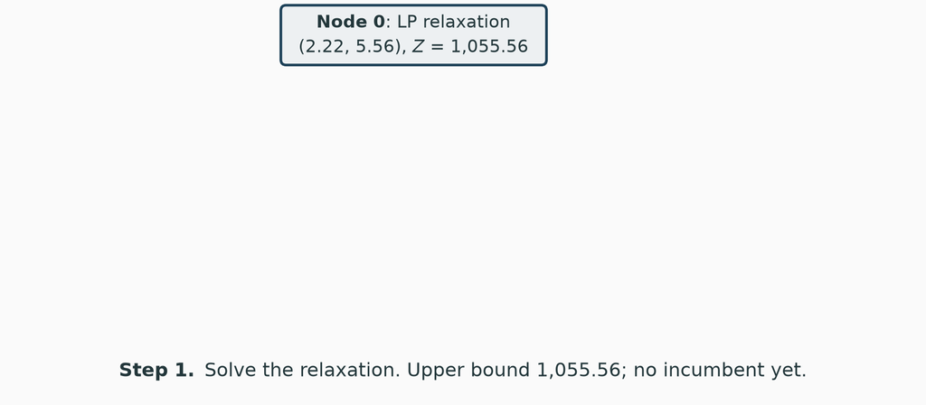

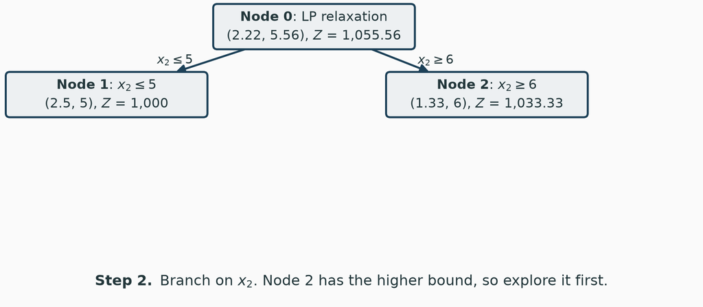

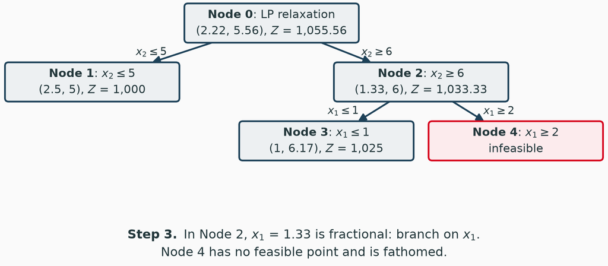

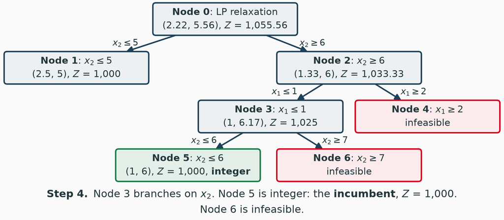

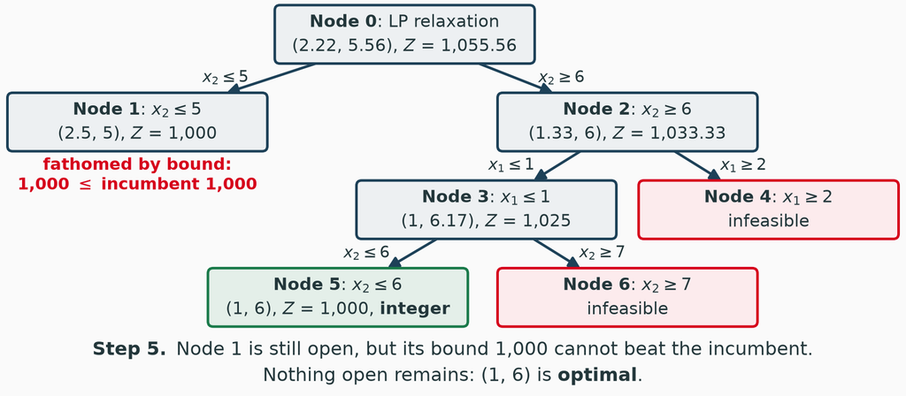

## What Branch and Bound Bought Us

**The machine shop’s answer**

Buy **1 press and 6 lathes**: $1,000 per day. Budget used $32,000 of $40,000; floor space 195 of 200 sq ft.

- 7 LPs solved; the bound at Node 1 closed off the $x_2 \le 5$ half without visiting its 27 lattice points
- The relaxation value $1{,}055.56$ is a **certificate**: no integer solution can exceed it

**Why this matters for you**

You will not run branch and bound by hand. You will read a solver’s **gap** between incumbent and bound, and decide whether 1% is good enough.

# Integer Models in Excel Solver

## The Spreadsheet Model: Same Layout as an LP

|  | A | B | C | E | F | G |
| --- | --- | --- | --- | --- | --- | --- |
| **3** |  | Presses ($x_1$) | Lathes ($x_2$) | Used |  | Available |
| **4** | Budget ($) | 8,000 | 4,000 | `=SUMPRODUCT(B4:C4,B8:C8)` | $\le$ | 40,000 |
| **5** | Floor space (sq ft) | 15 | 30 | `=SUMPRODUCT(B5:C5,B8:C8)` | $\le$ | 200 |
| **8** | Decision | $x_1$ | $x_2$ |  |  |  |
| **9** | Variable type | integer | integer |  |  |  |
| **11** | Profit per day ($) | 100 | 150 | `=SUMPRODUCT(B11:C11,B8:C8)` |  |  |

- Data cells, changing cells (B8:C8), output formulas, one objective cell (E11): the LP recipe, unchanged
- You declare the integer requirement in the Solver dialog as the constraint `B8:C8 = int`. No cell formula expresses it
- File: Machine_Shop.xlsx (opens at the optimum; reset the changing cells to 0 to watch Solver work)

## Solver Setup for an Integer Model

**Download Machine_Shop.xlsx and open it**

Go to Data $\to$ Solver. Check the dialog: objective E11 (Max), changing cells B8:C8, constraints E4:E5 $\le$ G4:G5 and `B8:C8 = integer`, Simplex LP, “Make Unconstrained Variables Non-Negative” checked.

- Add Constraint, pick the changing cells, choose **int** in the relation drop-down (**bin** for 0–1 variables)
- Solving method stays **Simplex LP**: Solver runs branch and bound on top of it

## One Option That Changes the Answer

**Download Machine_Shop.xlsx and open it**

In the Solver dialog click Options, tab All Methods, and read **Integer Optimality (%)**. Set it to 0 if it is not already.

**Integer Optimality (%)**

Solver stops as soon as the incumbent is within this percentage of the bound. The default (1%, older versions 5%) can return a **suboptimal** integer solution and call it done. Set it to **0** for the problems in this course.

With the tolerance at 0, Solver returns $x_1 = 1$, $x_2 = 6$, $Z = 1{,}000$, matching the branch and bound tree.

## The Solved Spreadsheet

**Download Machine_Shop.xlsx and open it**

Set the changing cells B8:C8 to 0, run Solver, and confirm B8 $=1$, C8 $=6$, E4 $=32{,}000$, E5 $=195$, E11 $=1{,}000$. Then remove the `integer` constraint, solve again, and compare.

Budget used $32,000, floor space 195 sq ft, profit $1,000/day. Both resources have slack: integer optima need not touch a constraint.

# A 0–1 Integer Model: Recreation Facilities

## Recreation Facilities

A town selects facilities to maximize expected daily usage by residents.

- Budget **$120,000**; land **12 acres**
- Selection rule: **either** the swimming pool **or** the tennis center, not both

| Facility | Usage (people/day) | Cost ($) | Land (acres) |
| --- | --- | --- | --- |
| Swimming pool | 300 | 35,000 | 4 |
| Tennis center | 90 | 10,000 | 2 |
| Athletic field | 400 | 25,000 | 7 |
| Gymnasium | 150 | 90,000 | 3 |

## The Recreation Facilities Model

**0–1 model: $x_1$ pool, $x_2$ tennis, $x_3$ field, $x_4$ gym; $x_j = 1$ if built**

$$\small
\begin{array}{l@{\;\;}r@{\;}r@{\;}r@{\;}r@{\;}c@{\;}l@{\;\;}l}
\max~ Z = & 300x_1 & {}+90x_2 & {}+400x_3 & {}+150x_4 \\
\text{subject to} & 35{,}000x_1 & {}+10{,}000x_2 & {}+25{,}000x_3 & {}+90{,}000x_4 & \le & 120{,}000 & \text{(budget)} \\
& 4x_1 & {}+2x_2 & {}+7x_3 & {}+3x_4 & \le & 12 & \text{(acres)} \\
& x_1 & {}+x_2 & & & \le & 1 & \text{(pool or tennis)} \\
& \rlap{x_1, x_2, x_3, x_4 = 0 \text{ or } 1}\phantom{35{,}000x_1}
\end{array}$$

- $x_1 + x_2 \le 1$ says “at most one of the two.” Binary variables turn business rules into linear inequalities; more patterns later in this deck

## Recreation Facilities in Excel

**Download Recreation_Facilities.xlsx and open it**

Open Data $\to$ Solver: objective G12 (Max), changing cells B9:E9, constraints G4:G6 $\le$ I4:I6, and `B9:E9 = bin`. Row 6 is the either/or rule.

- Declare the changing cells **bin**: Solver adds $0 \le x_j \le 1$ and integrality in one step
- The either/or rule is an ordinary constraint row: coefficients $1, 1, 0, 0$, right-hand side 1

## Recreation Facilities: Solution

**Download Recreation_Facilities.xlsx and open it**

Reset B9:E9 to 0, run Solver, and confirm B9:E9 $= 1, 0, 1, 0$ and G12 $=700$. Then drop the either/or row from the constraints: what changes?

**The town’s answer**

Build the **swimming pool and the athletic field**: 700 people per day. Cost $60,000 of $120,000; land 11 of 12 acres. The gymnasium is too expensive per user; the tennis center loses to the pool.

# A Mixed Integer Model: Investments

## An Investment Portfolio

$250,000 is available for investments that earn the greatest return after one year.

| Investment | Cost | Profit after 1 year | Available |
| --- | --- | --- | --- |
| Condominium | $50,000/unit | $9,000/unit | 4 units |
| Land | $12,000/acre | $1,500/acre | 15 acres |
| Municipal bond | $8,000/bond | $1,000/bond | 20 bonds |

**Which decisions are integers?**

Condominiums and bonds trade in whole units. Land can be bought by the fraction of an acre. A **mixed** integer model.

## The Investment Model

**Mixed integer model: $x_1$ condominiums, $x_2$ acres of land, $x_3$ bonds**

$$\begin{array}{l@{\;\;}r@{\;}r@{\;}r@{\;}c@{\;}l@{\quad}l}
\max~ Z = & 9{,}000x_1 & {}+1{,}500x_2 & {}+1{,}000x_3 \\
\text{subject to} & 50{,}000x_1 & {}+12{,}000x_2 & {}+8{,}000x_3 & \le & 250{,}000 & \text{(funds, \$)} \\
& x_1 & & & \le & 4 & \text{(condominiums)} \\
& & x_2 & & \le & 15 & \text{(acres)} \\
& & & x_3 & \le & 20 & \text{(bonds)} \\
& \rlap{x_2 \ge 0; \quad x_1,\; x_3 \ge 0 \text{ and integer}}\phantom{50{,}000x_1}
\end{array}$$

- Return per dollar: condos 18%, land 12.5%, bonds 12.5%. Expect the money to go to condominiums first; land and bonds tie for the leftover

## Investments in Excel

**Download Investment_Mixed.xlsx and open it**

Open Solver: F4 $\le$ H4, B7:D7 $\le$ B9:D9, `B7 = int`, `D7 = int`; C7 stays continuous. Reset B7:D7 to 0, solve, and confirm B7 $=4$ and F11 $=42{,}250$. How did Solver split C7 and D7?

**The portfolio**

**4 condominiums** absorb $200,000, and the remaining $50,000 goes to land, bonds, or both: $42,250 profit. Land and bonds both return 12.5%, so the $50,000 earns $6,250 however it is split. The optimum is not unique: 0 to 6 bonds, with the rest in land, all give $42,250. Solver reports one of them, such as 4.17 acres and 0 bonds.

# 0–1 Modeling Patterns

## Three Classic 0–1 Structures

Binary variables model choices that LP cannot express. Three patterns cover most applications:

**Capital budgeting**

Which projects to fund under multi-year budgets, with mutually exclusive options.

**Fixed charge**

Pay a fixed cost only if a facility is used; continuous flows linked to a binary switch.

**Set covering**

Fewest facilities so that every customer is within reach of at least one.

## Capital Budgeting: University Bookstore

The bookstore is expanding. Five candidate projects compete for funds over three years, and there is not enough space for both a computer department and a clothing department.

All amounts in $1,000s.

| Project | NPV return | Year 1 cost | Year 2 cost | Year 3 cost |
| --- | --- | --- | --- | --- |
| 1. Web site | 120 | 55 | 40 | 25 |
| 2. Warehouse | 85 | 45 | 35 | 20 |
| 3. Clothing department | 105 | 60 | 25 | 0 |
| 4. Computer department | 140 | 50 | 35 | 30 |
| 5. ATMs | 70 | 30 | 30 | 0 |
| **Available funds** |  | **150** | **110** | **60** |

## The Capital Budgeting Model

**0–1 model: $x_i = 1$ if project $i$ is selected, $0$ if not, $i = 1, \dots, 5$**

$$\begin{array}{l@{\;\;}r@{\;}r@{\;}r@{\;}r@{\;}r@{\;}c@{\;}l@{\quad}l}
\max~ Z = & 120x_1 & {}+85x_2 & {}+105x_3 & {}+140x_4 & {}+70x_5 \\
\text{subject to} & 55x_1 & {}+45x_2 & {}+60x_3 & {}+50x_4 & {}+30x_5 & \le & 150 & \text{(year 1)} \\
& 40x_1 & {}+35x_2 & {}+25x_3 & {}+35x_4 & {}+30x_5 & \le & 110 & \text{(year 2)} \\
& 25x_1 & {}+20x_2 & & {}+30x_4 & & \le & 60 & \text{(year 3)} \\
& & & x_3 & {}+x_4 & & \le & 1 & \text{(space)} \\
& \rlap{x_i = 0 \text{ or } 1}\phantom{120x_1}
\end{array}$$

The space conflict becomes one inequality: $x_3 + x_4 \le 1$.

## Business Rules as Binary Constraints

| Rule | Constraint |
| --- | --- |
| At most one of projects 3 and 4 | $x_3 + x_4 \le 1$ |
| Exactly one of a set $S$ | $\sum_{i \in S} x_i = 1$ |
| Project 2 only if project 1 is chosen | $x_2 \le x_1$ |
| Projects 1 and 2 together or not at all | $x_1 = x_2$ |
| At least two of projects 1, 2, 5 | $x_1 + x_2 + x_5 \ge 2$ |
| If project 3 then not project 5 | $x_3 + x_5 \le 1$ |

**The pattern**

Write the rule in words, then check the inequality on every combination of the variables involved.

## Capital Budgeting: Solution

**Download Capital_Budgeting.xlsx and open it**

Reset B10:F10 to 0, run Solver (`B10:F10 = bin`), and confirm B10:F10 $= 1, 0, 0, 1, 1$ and H13 $=330$. Which budget years have the least slack?

**The bookstore’s answer**

Fund the **web site, the computer department, and the ATMs**: NPV $330,000. Year 1 spends 135 of 150, year 2 105 of 110, year 3 55 of 60. Adding the warehouse (85) would exceed all three yearly budgets (180, 140 and 75 against 150, 110 and 60); the clothing department is excluded by the computer department.

## Fixed Charge and Facility Location: Potato Farms

A food company will buy some of six farms to supply three processing plants at minimum total cost: annual **fixed cost** of each farm purchased plus **shipping** cost per ton.

| Farm | Fixed ($1,000s) | Harvest (1,000 t) |
| --- | --- | --- |
| 1 | 405 | 11.2 |
| 2 | 390 | 10.5 |
| 3 | 450 | 12.8 |
| 4 | 368 | 9.3 |
| 5 | 520 | 10.8 |
| 6 | 465 | 9.6 |

| Plant | Capacity (1,000 tons) |
| --- | --- |
| A | 12 |
| B | 10 |
| C | 14 |

Plants must run at capacity: 36,000 tons in total. The six farms could harvest 64,200.

## Shipping Costs and Decisions

Shipping cost, $ per ton.

| Farm | Plant A | Plant B | Plant C |
| --- | --- | --- | --- |
| 1 | 18 | 15 | 12 |
| 2 | 13 | 10 | 17 |
| 3 | 16 | 14 | 18 |
| 4 | 19 | 15 | 16 |
| 5 | 17 | 19 | 12 |
| 6 | 14 | 16 | 12 |

**Decisions.**

- $y_i = 1$ if farm $i$ is purchased, $0$ if not; $i = 1, \dots, 6$
- $x_{ij}$ = potatoes shipped from farm $i$ to plant $j$ (1,000 tons); $j = A, B, C$

**Two kinds of variables**

A binary switch per farm, a continuous flow per farm-plant pair: **mixed** integer, 6 binaries and 18 continuous variables.

## The Fixed Charge Model

**Fixed charge and facility location model**

$$\small
\begin{array}{@{}l@{}}
\begin{array}{l@{\;}l}
\min~ Z = & 18x_{1A} + 15x_{1B} + 12x_{1C} + 13x_{2A} + 10x_{2B} + 17x_{2C}
+ 16x_{3A} + 14x_{3B} + 18x_{3C} \\
& {}+ 19x_{4A} + 15x_{4B} + 16x_{4C} + 17x_{5A} + 19x_{5B} + 12x_{5C}
+ 14x_{6A} + 16x_{6B} + 12x_{6C} \\
& {}+ 405y_1 + 390y_2 + 450y_3 + 368y_4 + 520y_5 + 465y_6
\end{array} \\[3pt]
\begin{array}{l@{\;\;}r@{\;}r@{\;}r@{\;}r@{\;}c@{\;}l@{\quad}l}
\text{subject to} & x_{1A} & {}+x_{1B} & {}+x_{1C} & {}-11.2y_1 & \le & 0 & \text{(farm 1 supply)} \\
& x_{2A} & {}+x_{2B} & {}+x_{2C} & {}-10.5y_2 & \le & 0 & \text{(farm 2 supply)} \\
& x_{3A} & {}+x_{3B} & {}+x_{3C} & {}-12.8y_3 & \le & 0 & \text{(farm 3 supply)} \\
& x_{4A} & {}+x_{4B} & {}+x_{4C} & {}-9.3y_4 & \le & 0 & \text{(farm 4 supply)} \\
& x_{5A} & {}+x_{5B} & {}+x_{5C} & {}-10.8y_5 & \le & 0 & \text{(farm 5 supply)} \\
& x_{6A} & {}+x_{6B} & {}+x_{6C} & {}-9.6y_6 & \le & 0 & \text{(farm 6 supply)}
\end{array} \\[3pt]
\begin{array}{l@{\;\;}r@{\;}r@{\;}r@{\;}r@{\;}r@{\;}r@{\;}c@{\;}l@{\quad}l}
\phantom{\text{subject to}} & x_{1A} & {}+x_{2A} & {}+x_{3A} & {}+x_{4A} & {}+x_{5A} & {}+x_{6A} & = & 12 & \text{(plant A demand)} \\
& x_{1B} & {}+x_{2B} & {}+x_{3B} & {}+x_{4B} & {}+x_{5B} & {}+x_{6B} & = & 10 & \text{(plant B demand)} \\
& x_{1C} & {}+x_{2C} & {}+x_{3C} & {}+x_{4C} & {}+x_{5C} & {}+x_{6C} & = & 14 & \text{(plant C demand)} \\
& \rlap{x_{ij} \ge 0, \qquad y_i = 0 \text{ or } 1}\phantom{x_{1A}}
\end{array}
\end{array}$$

## The Linking Constraint

**Fixed charge link**

$$\sum_{j} x_{ij} \;\le\; (\text{harvest}_i)\, y_i$$

If $y_i = 0$, nothing ships from farm $i$. If $y_i = 1$, the farm can ship up to its harvest, and the objective pays its fixed cost.

- The harvest plays the role of a **big-M**: an upper bound that never binds when the switch is on
- Minimization does the rest: $y_i = 1$ without shipping would pay a fixed cost for nothing
- Units: $/ton times 1,000 tons gives $1,000s, the same unit as the fixed costs

## Fixed Charge: Solution

**Download Fixed_Charge_Farms.xlsx and open it**

Two blocks of changing cells: shipments B13:D18 and farm switches H13:H18 (`bin`). Column G holds harvest $\times$ switch, the linking constraint. Reset both blocks to 0, solve, and confirm B25 $= 2{,}082.3$.

Shipments, 1,000 tons. One of several optimal shipping plans.

| Farm | A | B | C |
| --- | --- | --- | --- |
| 1 | 0 | 0 | 11.2 |
| 2 | 2.4 | 8.1 | 0 |
| 4 | 0 | 1.9 | 2.8 |
| 6 | 9.6 | 0 | 0 |

**The company’s answer**

Buy **farms 1, 2, 4, and 6**. Total cost $2,082,300: fixed $1,628,000 plus shipping $454,300. Every plan needs four farms, since the three largest harvest only 34,800 tons. Farm 3 has the largest harvest and the lowest fixed cost per ton, yet swapping it in for farm 6 saves $15,000 in fixed cost and adds $15,400 in shipping.

## Set Covering: Parcel Hubs

A parcel carrier (APS) will build hubs in some of twelve cities so that **every city has a hub within 300 miles**, using as few hubs as possible.

| City | Cities within 300 miles |
| --- | --- |
| 1. Atlanta | Atlanta, Charlotte, Nashville |
| 2. Boston | Boston, New York |
| 3. Charlotte | Atlanta, Charlotte, Richmond |
| 4. Cincinnati | Cincinnati, Detroit, Indianapolis, Nashville, Pittsburgh |
| 5. Detroit | Cincinnati, Detroit, Indianapolis, Milwaukee, Pittsburgh |
| 6. Indianapolis | Cincinnati, Detroit, Indianapolis, Milwaukee, Nashville, St. Louis |

## Set Covering: Parcel Hubs (Continued)

| City | Cities within 300 miles |
| --- | --- |
| 7. Milwaukee | Detroit, Indianapolis, Milwaukee |
| 8. Nashville | Atlanta, Cincinnati, Indianapolis, Nashville, St. Louis |
| 9. New York | Boston, New York, Richmond |
| 10. Pittsburgh | Cincinnati, Detroit, Pittsburgh, Richmond |
| 11. Richmond | Charlotte, New York, Pittsburgh, Richmond |
| 12. St. Louis | Indianapolis, Nashville, St. Louis |

## The Set Covering Model

**0–1 model: $x_i = 1$ if city $i$ gets a hub, $0$ if not; one constraint per city**

$$\small
\begin{array}{l@{\;\;}r@{\,}r@{\,}r@{\,}r@{\,}r@{\,}r@{\,}r@{\,}r@{\,}r@{\,}r@{\,}r@{\,}r@{\;}c@{\;}l@{\quad}l}
\min~ Z = & x_1 & {}+x_2 & {}+x_3 & {}+x_4 & {}+x_5 & {}+x_6 & {}+x_7 & {}+x_8 & {}+x_9 & {}+x_{10} & {}+x_{11} & {}+x_{12} \\
\text{subject to} & x_1 & & {}+x_3 & & & & & {}+x_8 & & & & & \ge & 1 & \text{(Atlanta)} \\
& & x_2 & & & & & & & {}+x_9 & & & & \ge & 1 & \text{(Boston)} \\
& x_1 & & {}+x_3 & & & & & & & & {}+x_{11} & & \ge & 1 & \text{(Charlotte)} \\
& & & & x_4 & {}+x_5 & {}+x_6 & & {}+x_8 & & {}+x_{10} & & & \ge & 1 & \text{(Cincinnati)} \\
& & & & x_4 & {}+x_5 & {}+x_6 & {}+x_7 & & & {}+x_{10} & & & \ge & 1 & \text{(Detroit)} \\
& & & & x_4 & {}+x_5 & {}+x_6 & {}+x_7 & {}+x_8 & & & & {}+x_{12} & \ge & 1 & \text{(Indianapolis)} \\
& & & & & x_5 & {}+x_6 & {}+x_7 & & & & & & \ge & 1 & \text{(Milwaukee)} \\
& x_1 & & & {}+x_4 & & {}+x_6 & & {}+x_8 & & & & {}+x_{12} & \ge & 1 & \text{(Nashville)} \\
& & x_2 & & & & & & & {}+x_9 & & {}+x_{11} & & \ge & 1 & \text{(New York)} \\
& & & & x_4 & {}+x_5 & & & & & {}+x_{10} & {}+x_{11} & & \ge & 1 & \text{(Pittsburgh)} \\
& & & x_3 & & & & & & {}+x_9 & {}+x_{10} & {}+x_{11} & & \ge & 1 & \text{(Richmond)} \\
& & & & & & x_6 & & {}+x_8 & & & & {}+x_{12} & \ge & 1 & \text{(St.\ Louis)} \\
& \rlap{x_i = 0 \text{ or } 1}\phantom{x_1}
\end{array}$$

## Set Covering: Solution

**Download Set_Covering_Hubs.xlsx and open it**

Rows 4 to 15: coverage matrix; row 17: hub switches (`bin`); column N: hubs covering each city. Reset row 17 to 0, solve, and confirm B20 $=4$.

**The carrier’s answer**

**4 hubs** suffice, for example Indianapolis, Nashville, New York, and Richmond. No set of 3 cities covers all twelve.

**Alternative optima**

26 different 4-hub sets cover every city; Solver reports one of them. The manager still chooses *which* 4, on grounds the model omits.

# Practice: Salespeople Transfer

## Practice Problem

**Publishing company: two new regions**

A publishing company is developing two new sales regions and plans to transfer some of its **10 salespeople** into them.

- Annual expenses per salesperson: Region 1 **$10,000**, Region 2 **$7,500**; total expense budget **$72,000**
- Sales generated per salesperson per year: Region 1 **$85,000**, Region 2 **$60,000**

How many salespeople should be transferred into each region to maximize the increase in sales?

## Practice Problem: What to Do

- **Step 1.** Formulate the integer programming model: decisions, objective, constraints, integrality.
- **Step 2.** Solve it with Excel Solver. Salespeople_Transfer.xlsx has the layout; reset the changing cells to 0 first and set Integer Optimality to 0.
- **Step 3.** Solve the LP relaxation (remove the `int` constraint). Does rounding work this time? Why?

**Hint**

Compare sales generated per expense dollar in the two regions before you solve anything. Solution in the appendix.

# Conclusions

## Conclusions

- Integer programming keeps the LP grammar and adds one requirement: whole units or yes/no decisions
- The requirement is expensive to enforce: rounding fails, and the method that works is a tree search that solves many LPs
- Binary variables are a modeling language for business rules: either/or, if-then, fixed costs, coverage
- In Excel the only change is the `int` or `bin` constraint, plus the Integer Optimality tolerance set to 0

## Summary

**Core takeaways**

- Total, 0–1, and mixed integer models
- LP relaxation gives a bound, not an answer
- Branch and bound: relax, branch, bound

**Watch out for**

- Rounding an LP solution
- Solver’s default integer tolerance
- Alternative optima the model cannot rank

**Bottom line**

Declare integrality where the business demands it, let the solver run the search, and read the gap before you trust the answer.

## Questions?

Introduction to Integer Programming

MGMT 6460

# Appendix

## Appendix: Salespeople Transfer, Formulation

**Total integer model: $x_1$, $x_2$ = salespeople transferred to Regions 1, 2**

$$\begin{array}{l@{\;\;}r@{\;}r@{\;}c@{\;}l@{\quad}l}
\max~ Z = & 85{,}000x_1 & {}+60{,}000x_2 \\
\text{subject to} & 10{,}000x_1 & {}+7{,}500x_2 & \le & 72{,}000 & \text{(expense budget)} \\
& x_1 & {}+x_2 & \le & 10 & \text{(salespeople available)} \\
& \rlap{x_1,\; x_2 \ge 0 \text{ and integer}}\phantom{85{,}000x_1}
\end{array}$$

- Sales per expense dollar: Region 1 $8.50, Region 2 $8.00. The budget binds long before the headcount does

## Appendix: Salespeople Transfer, Solution

**LP relaxation.** All money to Region 1: $x_1 = 72{,}000 / 10{,}000 = 7.2$, $x_2 = 0$, $Z = 612{,}000$.

**Integer optimum.** $x_1 = 7$, $x_2 = 0$, $Z = \$595{,}000$. Expenses $70,000 of $72,000; 3 salespeople stay put.

**Runner-up.** $(4, 4)$: expenses $70,000, $Z = \$580{,}000$.

**Rounding worked this time**

Rounding 7.2 down to 7 is optimal because the $2,000 left over cannot fund a Region 2 salesperson ($7,500). Rounding is a heuristic that sometimes lands on the optimum; branch and bound is what proves it.

**Excel**

Salespeople_Transfer.xlsx: objective E11, changing cells B8:C8, `B8:C8 = int`.

## Appendix: Verification in Python (gurobipy)

```python
import gurobipy as gp
from gurobipy import GRB

m  = gp.Model("machine_shop")
x1 = m.addVar(vtype=GRB.INTEGER, name="presses")
x2 = m.addVar(vtype=GRB.INTEGER, name="lathes")
m.setObjective(100*x1 + 150*x2, GRB.MAXIMIZE)
m.addConstr(8000*x1 + 4000*x2 <= 40000, name="budget")
m.addConstr(  15*x1 +   30*x2 <=   200, name="space")
m.optimize()
print(x1.X, x2.X, m.ObjVal)   # 1.0 6.0 1000.0

# vtype=GRB.BINARY for 0-1 variables; omit vtype for continuous ones.
# m.relax() returns the LP relaxation: (2.22, 5.56), 1055.56.
```

One keyword argument, `vtype`, turns an LP into an IP. Every optimum in this deck was checked this way; the set covering model was also enumerated to count its 26 alternative optima.

## Appendix: Resources

**Companion workbooks**, one click to download: Machine_Shop.xlsx, Recreation_Facilities.xlsx, Investment_Mixed.xlsx, Capital_Budgeting.xlsx, Fixed_Charge_Farms.xlsx, Set_Covering_Hubs.xlsx, Salespeople_Transfer.xlsx. Each opens at the verified optimum with the Solver model already entered.

**Software resources**  
Intro to gurobipy: [gurobi.github.io/modeling-examples](https://gurobi.github.io/modeling-examples/intro_to_gurobipy/)  
Beginner notebooks: [gurobi.com/jupyter_models](https://www.gurobi.com/jupyter_models/)